# Part 2: Explanatory data analysis of the FordGo Bike dataset

In this second part of the analysis of our dataset, we will go deeper into analyses and we will try to give some insights for the owners of the bikes system and their users.

# Univariate Exploration

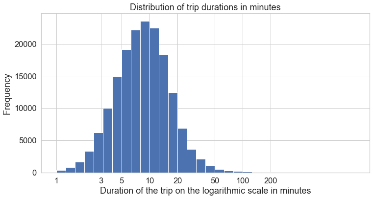

**Comment:** Most trips are about 3-20 minutes. If an user wants to be in TOP 1 of most fit users, this user should use the bike for at least 53 minutes. This summary statistics may be used to promote the gamification of this bikes to spread healthy lifestyle among bike users. As we have mobile apps that counts our steps during the days, we can do similar app that counts the kilometers that users make during the year. Users would compete with their coworkers.  
It can be used to choose what kind of tickets, we should offer for the customes of these bikes. One can suggest one option for short trips up to 20 minutes and second option, which will be more expensive for trip, which are longer than 20 minutes.

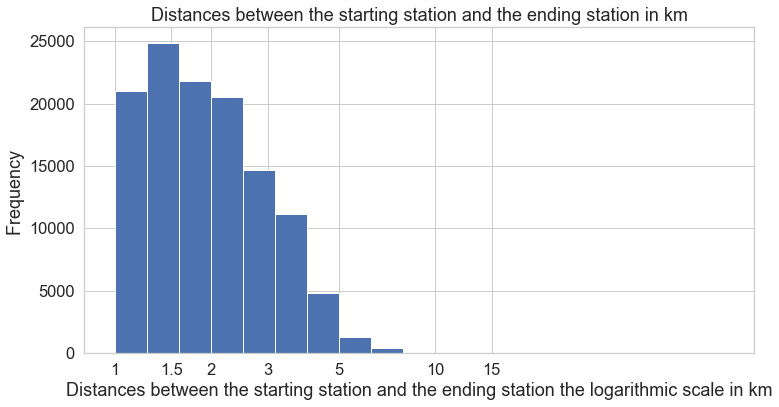

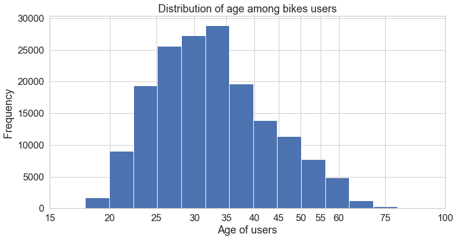

**Comment:** This distribution is probably a result of age limitation among younger users. The user has probably to be at least 18 years old to use these bikes. Should the owners of the system, consider younger generation to be allowed to use this system too? How can we motivate younger generations between (18-25 years old) and older generations (over 60 years old) to use more bikes?

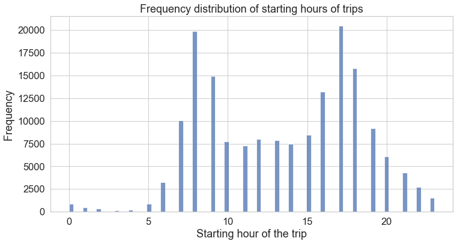

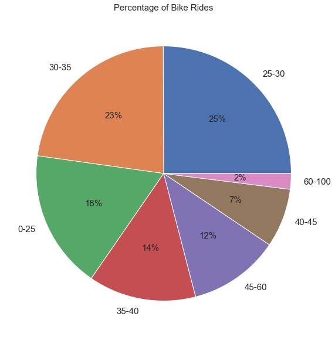

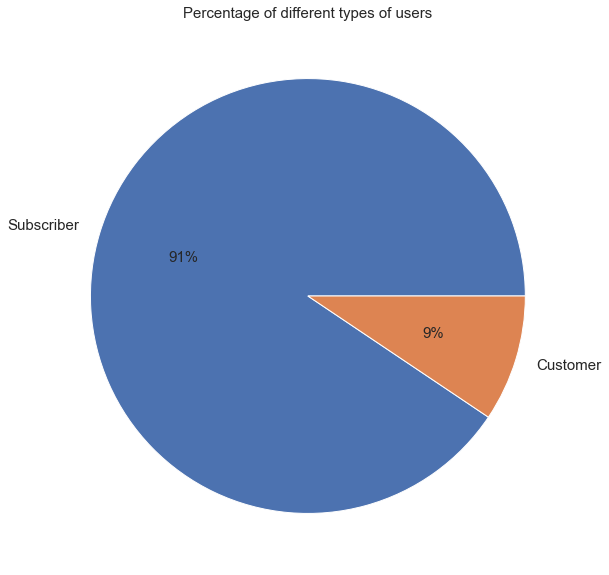

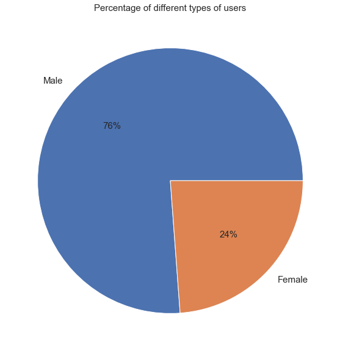

**Comment:** The typical user of bikes is a male who is a subscriber who is probably between 25 and 50 years old.

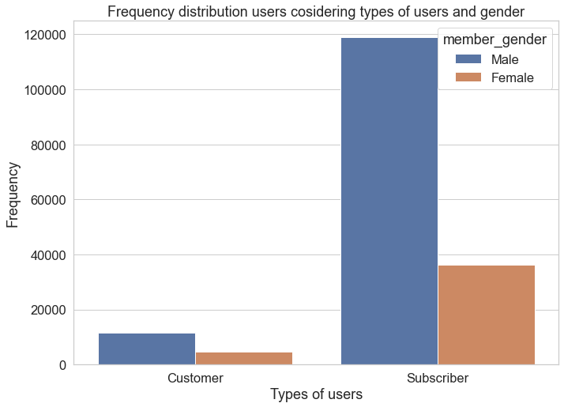

**Comment:** There are far more men than women who use bikes among customers as well as subscribers. This simple distribution may push us to ask ourself why women use far less bikes than men? Are bikes too heavy for most women, are bikes not too comfortable for women, what can we do to attract more women to use bikes?  
One may ask also, if the payment for customers is too complicated? Do the customers have to put too much time to use bikes or is it simply related to the small number of tourists who use it compared to subricribers who are mostly locals?

[figure not shown]

**Comment:** For some reason, subscibers use less bikes on Saturday and Sunday. The owners of the system want probably that their bikes are used most of the time and uniformly over all days of the week. We can suggest to make some kind of promotional offers to incentivize users to use it more during weekends.

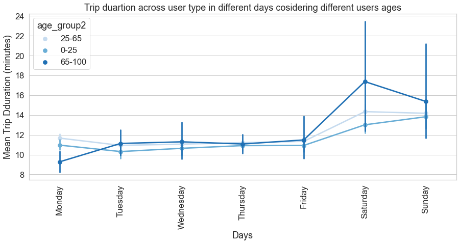

**Comment:** All group ages use bikes longer on weekends. I was expecting retired old people to use bikes longer during weekdays, but they probably use it during weekends with younger folks. But this difference is still weak, even though most people have more time on weekends, their trips on weekends are on average slightly longer.

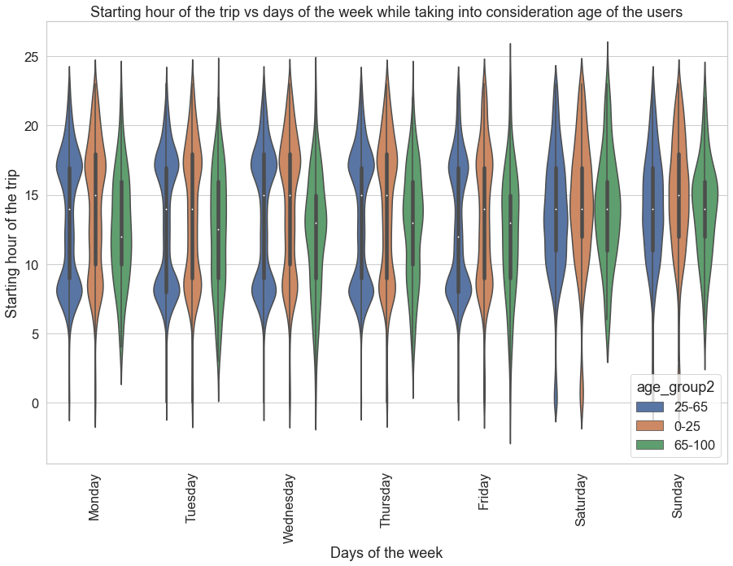

**Comment:** As we can see, older and probably not working/retired people use mostly bikes in them middle of the day. Mostly working age people 25-65 years old use bikes before and after work during working days. Young people find themselves somewhere between old and working people as they have school or college with more flexibile hours than working people. As we saw on one of previous distributions, old people and young people are using bikes less than the group of 25 to 67 years old people. As these 3 groups, use bikes differently, it would be wise to motivate older people to use bikes more to make more out of this system.

# Discussion

Even this seemingly simple dataset had some serious errors due to unrealistic outliers regarding for age of 143, which means that the verification process should double check the data we put into the system.  
Older people have similar duration time of trips as younger people. Women use bikes less often than men. Older and younger people use bikes less often than people who are between 25 and 50 years old. There are far more subscribers than occasional customers of the system. I was expecting strong positive correlation between the distances between stations and duration of trips.  
We could create an app for users of bikes to motivate them to use bikes more. The app would contain some summary statistics and rankings to allow users to compare their performances against the average user. We could make some promotional offers during weekends and during hours when the system is used less.